# Prosper Loan Data Analysis

## Introduction

```
 The data set contains 113,937 loans with 81 variables on each loan, including loan amount, borrower rate (or interest rate), current loan status, borrower income, and many others. The dataset primarily consists of data on the borrower's and the loan performance information.
```

## Preliminary Wrangling

```python
# import all packages and set plots to be embedded inline
import numpy as np
import pandas as pd
import matplotlib.pyplot as plt
import seaborn as sb

%matplotlib inline
```

> I will now load the dataset to review its structure and columns of concern that I will utilize for this analysis.

```python
df = pd.read_csv('prosperLoanData.csv')
print(df.shape)
print(df.dtypes)
df.head()
```

```
(113937, 81)
ListingKey                      object
ListingNumber                    int64
ListingCreationDate             object
CreditGrade                     object
Term                             int64
                                ...
PercentFunded                  float64
Recommendations                  int64
InvestmentFromFriendsCount       int64
InvestmentFromFriendsAmount    float64
Investors                        int64
Length: 81, dtype: object
```

|  | ListingKey | ListingNumber | ListingCreationDate | CreditGrade | Term | LoanStatus | ClosedDate | BorrowerAPR | BorrowerRate | LenderYield | ... | LP_ServiceFees | LP_CollectionFees | LP_GrossPrincipalLoss | LP_NetPrincipalLoss | LP_NonPrincipalRecoverypayments | PercentFunded | Recommendations | InvestmentFromFriendsCount | InvestmentFromFriendsAmount | Investors |
| --- | --- | --- | --- | --- | --- | --- | --- | --- | --- | --- | --- | --- | --- | --- | --- | --- | --- | --- | --- | --- | --- |
| 0 | 1021339766868145413AB3B | 193129 | 2007-08-26 19:09:29.263000000 | C | 36 | Completed | 2009-08-14 00:00:00 | 0.16516 | 0.1580 | 0.1380 | ... | -133.18 | 0.0 | 0.0 | 0.0 | 0.0 | 1.0 | 0 | 0 | 0.0 | 258 |
| 1 | 10273602499503308B223C1 | 1209647 | 2014-02-27 08:28:07.900000000 | NaN | 36 | Current | NaN | 0.12016 | 0.0920 | 0.0820 | ... | 0.00 | 0.0 | 0.0 | 0.0 | 0.0 | 1.0 | 0 | 0 | 0.0 | 1 |
| 2 | 0EE9337825851032864889A | 81716 | 2007-01-05 15:00:47.090000000 | HR | 36 | Completed | 2009-12-17 00:00:00 | 0.28269 | 0.2750 | 0.2400 | ... | -24.20 | 0.0 | 0.0 | 0.0 | 0.0 | 1.0 | 0 | 0 | 0.0 | 41 |
| 3 | 0EF5356002482715299901A | 658116 | 2012-10-22 11:02:35.010000000 | NaN | 36 | Current | NaN | 0.12528 | 0.0974 | 0.0874 | ... | -108.01 | 0.0 | 0.0 | 0.0 | 0.0 | 1.0 | 0 | 0 | 0.0 | 158 |
| 4 | 0F023589499656230C5E3E2 | 909464 | 2013-09-14 18:38:39.097000000 | NaN | 36 | Current | NaN | 0.24614 | 0.2085 | 0.1985 | ... | -60.27 | 0.0 | 0.0 | 0.0 | 0.0 | 1.0 | 0 | 0 | 0.0 | 20 |

5 rows × 81 columns

```python
df.info()
```

```
<class 'pandas.core.frame.DataFrame'>
RangeIndex: 113937 entries, 0 to 113936
Data columns (total 81 columns):
 #   Column                               Non-Null Count   Dtype
---  ------                               --------------   -----
 0   ListingKey                           113937 non-null  object
 1   ListingNumber                        113937 non-null  int64
 2   ListingCreationDate                  113937 non-null  object
 3   CreditGrade                          28953 non-null   object
 4   Term                                 113937 non-null  int64
 5   LoanStatus                           113937 non-null  object
 6   ClosedDate                           55089 non-null   object
 7   BorrowerAPR                          113912 non-null  float64
 8   BorrowerRate                         113937 non-null  float64
 9   LenderYield                          113937 non-null  float64
```

[output cut: 73 more lines]

```python
pd.set_option('display.max_rows', 400) # referenced stack over flow to display a sizeable amount of rows
df.isna().sum()
```

```
ListingKey                                  0
ListingNumber                               0
ListingCreationDate                         0
CreditGrade                             84984
Term                                        0
LoanStatus                                  0
ClosedDate                              58848
BorrowerAPR                                25
BorrowerRate                                0
LenderYield                                 0
EstimatedEffectiveYield                 29084
EstimatedLoss                           29084
EstimatedReturn                         29084
ProsperRating (numeric)                 29084
ProsperRating (Alpha)                   29084
ProsperScore                            29084
ListingCategory (numeric)                   0
BorrowerState                            5515
Occupation                               3588
EmploymentStatus                         2255
EmploymentStatusDuration                 7625
IsBorrowerHomeowner                         0
CurrentlyInGroup                            0
GroupKey                               100596
DateCreditPulled                            0
CreditScoreRangeLower                     591
CreditScoreRangeUpper                     591
FirstRecordedCreditLine                   697
CurrentCreditLines                       7604
OpenCreditLines                          7604
TotalCreditLinespast7years                697
OpenRevolvingAccounts                       0
OpenRevolvingMonthlyPayment                 0
InquiriesLast6Months                      697
TotalInquiries                           1159
CurrentDelinquencies                      697
AmountDelinquent                         7622
DelinquenciesLast7Years                   990
PublicRecordsLast10Years                  697
PublicRecordsLast12Months                7604
```

[output cut: 27 more lines]

```
MonthlyLoanPayment                          0
LP_CustomerPayments                         0
LP_CustomerPrincipalPayments                0
LP_InterestandFees                          0
LP_ServiceFees                              0
LP_CollectionFees                           0
LP_GrossPrincipalLoss                       0
LP_NetPrincipalLoss                         0
LP_NonPrincipalRecoverypayments             0
PercentFunded                               0
Recommendations                             0
InvestmentFromFriendsCount                  0
InvestmentFromFriendsAmount                 0
Investors                                   0
dtype: int64
```

## Assessing and Cleaning the Data to be ready for Exploratory Data Analysis.

To assess and clean the data, I will perform the following steps.

1. Decide on the columns that I will use for the analysis.
2. Subset the columns from the original data that I will use.
3. Drop any duplicated rows
4. Subset for rows with a ProsperRating value
5. Fill missing values
6. Change Datatypes

#### Deciding on the columns

```python
# I have reviewed the columns on Excel, with their definitions and have selected the following columns.
important_columns = ['ListingNumber','ListingCreationDate', 'ProsperScore', 'LoanOriginalAmount',\
                     'ListingCategory (numeric)', 'BorrowerState', 'BorrowerAPR', 'BorrowerRate', 'StatedMonthlyIncome',\
                     'ProsperRating (Alpha)', 'Occupation', 'Term','EmploymentStatus','DebtToIncomeRatio',\
                     'MonthlyLoanPayment', 'IsBorrowerHomeowner']
```

```python
# Creating the subset and titling it loan_df
loan_df = df[important_columns]
loan_df.sample(10)
```

|  | ListingNumber | ListingCreationDate | ProsperScore | LoanOriginalAmount | ListingCategory (numeric) | BorrowerState | BorrowerAPR | BorrowerRate | StatedMonthlyIncome | ProsperRating (Alpha) | Occupation | Term | EmploymentStatus | DebtToIncomeRatio | MonthlyLoanPayment | IsBorrowerHomeowner |
| --- | --- | --- | --- | --- | --- | --- | --- | --- | --- | --- | --- | --- | --- | --- | --- | --- |
| 30742 | 82141 | 2007-01-06 20:59:26.937000000 | NaN | 10000 | 0 | TX | 0.20735 | 0.2000 | 8666.666667 | NaN | Nurse (RN) | 36 | Not available | 0.16 | 371.64 | False |
| 34347 | 391034 | 2008-08-31 15:06:56.620000000 | NaN | 5175 | 6 | CO | 0.33393 | 0.3100 | 2916.666667 | NaN | Truck Driver | 36 | Full-time | 0.11 | 222.53 | False |
| 21751 | 546586 | 2011-12-25 09:42:10.283000000 | 5.0 | 3000 | 1 | NM | 0.24783 | 0.1496 | 5497.083333 | C | Attorney | 12 | Full-time | 0.43 | 270.72 | True |
| 105944 | 353664 | 2008-06-19 15:51:27.080000000 | NaN | 2000 | 3 | CA | 0.37453 | 0.3500 | 833.333333 | NaN | Teacher's Aide | 36 | Full-time | 1.02 | 90.47 | False |
| 23517 | 1133857 | 2014-01-28 07:52:23.227000000 | 10.0 | 25000 | 1 | PA | 0.12081 | 0.0930 | 12500.000000 | A | Sales - Retail | 36 | Employed | 0.15 | 798.49 | True |
| 61571 | 1146677 | 2014-01-18 12:03:24.550000000 | 4.0 | 7000 | 1 | TX | 0.19386 | 0.1570 | 2833.333333 | C | Police Officer/Correction Officer | 36 | Employed | 0.42 | 245.06 | True |
| 81738 | 313010 | 2008-04-17 16:05:11.850000000 | NaN | 2000 | 1 | WA | 0.17677 | 0.1550 | 3833.333333 | NaN | Other | 36 | Retired | 0.23 | 0.00 | False |
| 47299 | 958638 | 2013-10-04 10:50:05.283000000 | 3.0 | 4000 | 1 | IN | 0.30899 | 0.2699 | 3833.333333 | E | Other | 36 | Employed | 0.16 | 163.28 | False |
| 38615 | 876114 | 2013-08-21 15:29:43.800000000 | 6.0 | 3500 | 7 | CA | 0.18136 | 0.1579 | 4666.666667 | B | Administrative Assistant | 60 | Employed | 0.11 | 84.72 | False |
| 78280 | 1126568 | 2014-01-11 12:52:47.797000000 | 3.0 | 13000 | 1 | CA | 0.26149 | 0.2235 | 6250.000000 | D | Accountant/CPA | 36 | Employed | 0.28 | 498.83 | False |

```python
loan_df.info()
```

```
<class 'pandas.core.frame.DataFrame'>
RangeIndex: 113937 entries, 0 to 113936
Data columns (total 16 columns):
 #   Column                     Non-Null Count   Dtype
---  ------                     --------------   -----
 0   ListingNumber              113937 non-null  int64
 1   ListingCreationDate        113937 non-null  object
 2   ProsperScore               84853 non-null   float64
 3   LoanOriginalAmount         113937 non-null  int64
 4   ListingCategory (numeric)  113937 non-null  int64
 5   BorrowerState              108422 non-null  object
 6   BorrowerAPR                113912 non-null  float64
 7   BorrowerRate               113937 non-null  float64
 8   StatedMonthlyIncome        113937 non-null  float64
 9   ProsperRating (Alpha)      84853 non-null   object
 10  Occupation                 110349 non-null  object
 11  Term                       113937 non-null  int64
 12  EmploymentStatus           111682 non-null  object
 13  DebtToIncomeRatio          105383 non-null  float64
 14  MonthlyLoanPayment         113937 non-null  float64
 15  IsBorrowerHomeowner        113937 non-null  bool
dtypes: bool(1), float64(6), int64(4), object(5)
memory usage: 13.1+ MB
```

```python
loan_df.isna().sum()
```

```
ListingNumber                    0
ListingCreationDate              0
ProsperScore                 29084
LoanOriginalAmount               0
ListingCategory (numeric)        0
BorrowerState                 5515
BorrowerAPR                     25
BorrowerRate                     0
StatedMonthlyIncome              0
ProsperRating (Alpha)        29084
Occupation                    3588
Term                             0
EmploymentStatus              2255
DebtToIncomeRatio             8554
MonthlyLoanPayment               0
IsBorrowerHomeowner              0
dtype: int64
```

```python
## checking for duplicates and dropping them if they exist
loan_df.duplicated().sum()
```

```
0
```

```python
## Subsetting for only rows with ProsperRating values
loan_df = loan_df[~loan_df['ProsperRating (Alpha)'].isnull()]
loan_df['ProsperRating (Alpha)'].isnull().sum()
```

```
0
```

```python
loan_df.isna().sum()
```

```
ListingNumber                   0
ListingCreationDate             0
ProsperScore                    0
LoanOriginalAmount              0
ListingCategory (numeric)       0
BorrowerState                   0
BorrowerAPR                     0
BorrowerRate                    0
StatedMonthlyIncome             0
ProsperRating (Alpha)           0
Occupation                   1333
Term                            0
EmploymentStatus                0
DebtToIncomeRatio            7296
MonthlyLoanPayment              0
IsBorrowerHomeowner             0
dtype: int64
```

```python
## filling missing values for Occupation and Debttoincomeratio based on the structure of the data.

##filling missing values for Occupation with 'Unspecified'
loan_df.Occupation = loan_df.Occupation.fillna('Unspecified')

##filling missing values for DebtToIncomeRatio with the mean of the column
loan_df.DebtToIncomeRatio = loan_df.DebtToIncomeRatio.fillna(loan_df.DebtToIncomeRatio.mean())
```

```python
loan_df.info()
```

```
<class 'pandas.core.frame.DataFrame'>
Int64Index: 84853 entries, 1 to 113936
Data columns (total 16 columns):
 #   Column                     Non-Null Count  Dtype
---  ------                     --------------  -----
 0   ListingNumber              84853 non-null  int64
 1   ListingCreationDate        84853 non-null  object
 2   ProsperScore               84853 non-null  float64
 3   LoanOriginalAmount         84853 non-null  int64
 4   ListingCategory (numeric)  84853 non-null  int64
 5   BorrowerState              84853 non-null  object
 6   BorrowerAPR                84853 non-null  float64
 7   BorrowerRate               84853 non-null  float64
 8   StatedMonthlyIncome        84853 non-null  float64
 9   ProsperRating (Alpha)      84853 non-null  object
 10  Occupation                 84853 non-null  object
 11  Term                       84853 non-null  int64
 12  EmploymentStatus           84853 non-null  object
 13  DebtToIncomeRatio          84853 non-null  float64
 14  MonthlyLoanPayment         84853 non-null  float64
 15  IsBorrowerHomeowner        84853 non-null  bool
dtypes: bool(1), float64(6), int64(4), object(5)
memory usage: 10.4+ MB
```

```python
##Obtaining time,day, month and year from the ListingCreationDate column
loan_df['month'] = loan_df.ListingCreationDate.apply(lambda x: x.split("-")[1]).astype(str)
loan_df['year'] = loan_df.ListingCreationDate.apply(lambda x: x.split("-")[0]).astype(str)
loan_df['daytime'] = loan_df.ListingCreationDate.apply(lambda x: x.split("-")[2]).astype(str)
loan_df['day'] = loan_df.daytime.apply(lambda x: x.split(" ")[0]).astype(str)
loan_df['time'] = loan_df.daytime.apply(lambda x: x.split(" ")[1]).astype(str)
```

```python
## to review the new columns
loan_df.head()
```

|  | ListingNumber | ListingCreationDate | ProsperScore | LoanOriginalAmount | ListingCategory (numeric) | BorrowerState | BorrowerAPR | BorrowerRate | StatedMonthlyIncome | ProsperRating (Alpha) | ... | Term | EmploymentStatus | DebtToIncomeRatio | MonthlyLoanPayment | IsBorrowerHomeowner | month | year | daytime | day | time |
| --- | --- | --- | --- | --- | --- | --- | --- | --- | --- | --- | --- | --- | --- | --- | --- | --- | --- | --- | --- | --- | --- |
| 1 | 1209647 | 2014-02-27 08:28:07.900000000 | 7.0 | 10000 | 2 | CO | 0.12016 | 0.0920 | 6125.000000 | A | ... | 36 | Employed | 0.18 | 318.93 | False | 02 | 2014 | 27 08:28:07.900000000 | 27 | 08:28:07.900000000 |
| 3 | 658116 | 2012-10-22 11:02:35.010000000 | 9.0 | 10000 | 16 | GA | 0.12528 | 0.0974 | 2875.000000 | A | ... | 36 | Employed | 0.15 | 321.45 | True | 10 | 2012 | 22 11:02:35.010000000 | 22 | 11:02:35.010000000 |
| 4 | 909464 | 2013-09-14 18:38:39.097000000 | 4.0 | 15000 | 2 | MN | 0.24614 | 0.2085 | 9583.333333 | D | ... | 36 | Employed | 0.26 | 563.97 | True | 09 | 2013 | 14 18:38:39.097000000 | 14 | 18:38:39.097000000 |
| 5 | 1074836 | 2013-12-14 08:26:37.093000000 | 10.0 | 15000 | 1 | NM | 0.15425 | 0.1314 | 8333.333333 | B | ... | 60 | Employed | 0.36 | 342.37 | True | 12 | 2013 | 14 08:26:37.093000000 | 14 | 08:26:37.093000000 |
| 6 | 750899 | 2013-04-12 09:52:56.147000000 | 2.0 | 3000 | 1 | KS | 0.31032 | 0.2712 | 2083.333333 | E | ... | 36 | Employed | 0.27 | 122.67 | False | 04 | 2013 | 12 09:52:56.147000000 | 12 | 09:52:56.147000000 |

5 rows × 21 columns

```python
##drop redundant ListingCreationDate and daytime
loan_df.drop(['ListingCreationDate','daytime'], axis = 1, inplace=True)
```

```python
##Visually the month is in figures, I will confirm the unique months and change them to abbreviated alphabetic months
loan_df.month.unique()
```

```
array(['02', '10', '09', '12', '04', '05', '07', '08', '11', '01', '06',
       '03'], dtype=object)
```

```python
##the data contains all months and I will replace them
loan_df.month.replace(['02', '10', '09', '12', '04', '05', '07', '08', '11', '01', '06','03'],['Feb','Oct','Sep','Dec','Apr','May','Jul','Aug','Nov','Jan','Jun','Mar'],inplace=True)
```

```python
loan_df.month.unique()
```

```
array(['Feb', 'Oct', 'Sep', 'Dec', 'Apr', 'May', 'Jul', 'Aug', 'Nov',
       'Jan', 'Jun', 'Mar'], dtype=object)
```

```python
## replacing the listing category with the more descriptive meanings
listcategory_dict = {0 : 'Not Available', 1 : 'Debt Consolidation', 2 : 'Home Improvement', 3: 'Business',
             4 : 'Personal Loan', 5 : 'Student Use', 6 : 'Auto', 7 : 'Other', 8 : 'Baby&Adoption',
             9 : 'Boat', 10 : 'Cosmetic Procedure', 11 : 'Engagement Ring', 12 : 'Green Loans',
             13 : 'Household Expenses', 14 : 'Large Purchases', 15 : 'Medical/Dental', 16 : 'Motorcycle',
             17 : 'RV', 18 : 'Taxes', 19 : 'Vacation', 20 : 'Wedding Loans'}

loan_df['ListingCategory'] = loan_df['ListingCategory (numeric)'].map(listcategory_dict)
loan_df.drop(['ListingCategory (numeric)'], axis=1, inplace=True)
```

```python
loan_df.ListingCategory.unique()
```

```
array(['Home Improvement', 'Motorcycle', 'Debt Consolidation', 'Other',
       'Household Expenses', 'Auto', 'Medical/Dental', 'Wedding Loans',
       'Vacation', 'Taxes', 'Business', 'Baby&Adoption',
       'Engagement Ring', 'Large Purchases', 'Boat', 'RV',
       'Cosmetic Procedure', 'Not Available', 'Student Use',
       'Green Loans'], dtype=object)
```

```python
loan_df.head()
```

|  | ListingNumber | ProsperScore | LoanOriginalAmount | BorrowerState | BorrowerAPR | BorrowerRate | StatedMonthlyIncome | ProsperRating (Alpha) | Occupation | Term | EmploymentStatus | DebtToIncomeRatio | MonthlyLoanPayment | IsBorrowerHomeowner | month | year | day | time | ListingCategory |
| --- | --- | --- | --- | --- | --- | --- | --- | --- | --- | --- | --- | --- | --- | --- | --- | --- | --- | --- | --- |
| 1 | 1209647 | 7.0 | 10000 | CO | 0.12016 | 0.0920 | 6125.000000 | A | Professional | 36 | Employed | 0.18 | 318.93 | False | Feb | 2014 | 27 | 08:28:07.900000000 | Home Improvement |
| 3 | 658116 | 9.0 | 10000 | GA | 0.12528 | 0.0974 | 2875.000000 | A | Skilled Labor | 36 | Employed | 0.15 | 321.45 | True | Oct | 2012 | 22 | 11:02:35.010000000 | Motorcycle |
| 4 | 909464 | 4.0 | 15000 | MN | 0.24614 | 0.2085 | 9583.333333 | D | Executive | 36 | Employed | 0.26 | 563.97 | True | Sep | 2013 | 14 | 18:38:39.097000000 | Home Improvement |
| 5 | 1074836 | 10.0 | 15000 | NM | 0.15425 | 0.1314 | 8333.333333 | B | Professional | 60 | Employed | 0.36 | 342.37 | True | Dec | 2013 | 14 | 08:26:37.093000000 | Debt Consolidation |
| 6 | 750899 | 2.0 | 3000 | KS | 0.31032 | 0.2712 | 2083.333333 | E | Sales - Retail | 36 | Employed | 0.27 | 122.67 | False | Apr | 2013 | 12 | 09:52:56.147000000 | Debt Consolidation |

```python
loan_df.describe()
```

|  | ListingNumber | ProsperScore | LoanOriginalAmount | BorrowerAPR | BorrowerRate | StatedMonthlyIncome | Term | DebtToIncomeRatio | MonthlyLoanPayment |
| --- | --- | --- | --- | --- | --- | --- | --- | --- | --- |
| count | 8.485300e+04 | 84853.000000 | 84853.000000 | 84853.000000 | 84853.000000 | 8.485300e+04 | 84853.000000 | 84853.000000 | 84853.000000 |
| mean | 7.738749e+05 | 5.950067 | 9083.440515 | 0.226658 | 0.196022 | 5.931175e+03 | 42.486135 | 0.258752 | 291.930720 |
| std | 2.363387e+05 | 2.376501 | 6287.860058 | 0.079916 | 0.074631 | 8.239944e+03 | 11.640346 | 0.304333 | 186.678314 |
| min | 4.162750e+05 | 1.000000 | 1000.000000 | 0.045830 | 0.040000 | 0.000000e+00 | 12.000000 | 0.000000 | 0.000000 |
| 25% | 5.580860e+05 | 4.000000 | 4000.000000 | 0.163280 | 0.135900 | 3.434000e+03 | 36.000000 | 0.160000 | 157.330000 |
| 50% | 7.392460e+05 | 6.000000 | 7500.000000 | 0.219450 | 0.187500 | 5.000000e+03 | 36.000000 | 0.240000 | 251.940000 |
| 75% | 9.794360e+05 | 8.000000 | 13500.000000 | 0.292540 | 0.257400 | 7.083333e+03 | 60.000000 | 0.310000 | 388.350000 |
| max | 1.255725e+06 | 11.000000 | 35000.000000 | 0.423950 | 0.360000 | 1.750003e+06 | 60.000000 | 10.010000 | 2251.510000 |

```python
loan_df.info()
```

```
<class 'pandas.core.frame.DataFrame'>
Int64Index: 84853 entries, 1 to 113936
Data columns (total 19 columns):
 #   Column                 Non-Null Count  Dtype
---  ------                 --------------  -----
 0   ListingNumber          84853 non-null  int64
 1   ProsperScore           84853 non-null  float64
 2   LoanOriginalAmount     84853 non-null  int64
 3   BorrowerState          84853 non-null  object
 4   BorrowerAPR            84853 non-null  float64
 5   BorrowerRate           84853 non-null  float64
 6   StatedMonthlyIncome    84853 non-null  float64
 7   ProsperRating (Alpha)  84853 non-null  object
 8   Occupation             84853 non-null  object
 9   Term                   84853 non-null  int64
 10  EmploymentStatus       84853 non-null  object
 11  DebtToIncomeRatio      84853 non-null  float64
 12  MonthlyLoanPayment     84853 non-null  float64
 13  IsBorrowerHomeowner    84853 non-null  bool
 14  month                  84853 non-null  object
 15  year                   84853 non-null  object
 16  day                    84853 non-null  object
 17  time                   84853 non-null  object
 18  ListingCategory        84853 non-null  object
dtypes: bool(1), float64(6), int64(3), object(9)
memory usage: 12.4+ MB
```

### What is the structure of your dataset?

> The dataset (loan_df) now has 84,853 entries and 19 columns across the loan and borrowers information. There are numeric and qualitative data in the dataset. The prosperrating, BorrowerAPR, loan amount are some of the very important columns in the data.

### What is/are the main feature(s) of interest in your dataset?

> My main interest in my dataset is to find out what features can be used to predict the BorrowerAPR appropriately. How other features like the Occupation, Debttoincome ratio relate with other variables and affect the BoorowerAPR

### What features in the dataset do you think will help support your investigation into your feature(s) of interest?

> Having worked in the financial sector for several years, I know that a number of factors will affect BorrowerAPR like the following:
> 1. The Occupation and debttoincomeratio largely affects the risk and ease with which financial institutions avails loans, which should directly impact the APR
> 2. The loan amount should also affect the APR, as a higher loan amount should ordinarily mean a lower interest rate and APR
> 3. Being a homeowner should also affect APR as it means the borrower has a reasonable collateral for the loan

## Univariate Exploration

> In this section, I will investigate the distributions of some of the features.

## I will start off by reviewing the month, year and day that people have borrowed.

```python
## making the month data categorical
monthly_order = ['Jan','Feb','Mar','Apr','May','Jun','Jul','Aug','Sep','Oct','Nov','Dec']
monthly_dtype = pd.api.types.CategoricalDtype(ordered = True,
                                    categories = monthly_order)
loan_df['month'] = loan_df['month'].astype(monthly_dtype)
loan_df.groupby('month')['ListingNumber'].count()
```

```
month
Jan    9201
Feb    7963
Mar    5385
Apr    4906
May    5470
Jun    5808
Jul    6638
Aug    6443
Sep    7625
Oct    8728
Nov    8245
Dec    8441
Name: ListingNumber, dtype: int64
```

```python
def ordered_countploting(x,y):
    """this function will be used to create bar charts on loan_df with a defined order"""
    base_color = sb.color_palette()[0]
    plt.figure(figsize=[10,6])
    return sb.countplot(data = loan_df, x=x,color = base_color, order = y)

def countploting(x):
    """this function will be used to create bar charts on loan_df with a defined order"""
    base_color = sb.color_palette()[0]
    plt.figure(figsize=[10,6])
    return sb.countplot(data = loan_df, x=x,color = base_color)
```

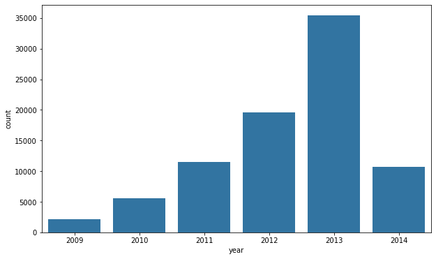

```python
ordered_countploting(loan_df.year, ['2009','2010','2011','2012','2013','2014']);
```

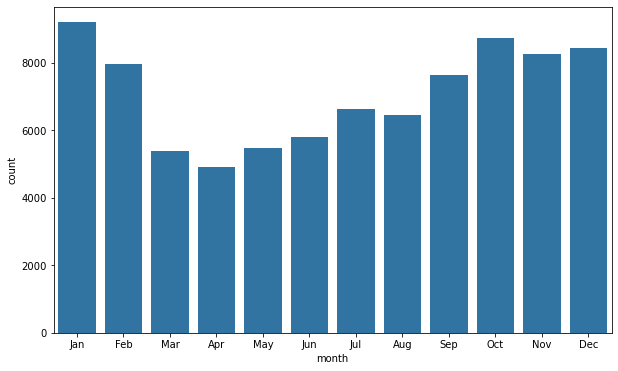

```python
countploting(loan_df.month);
```

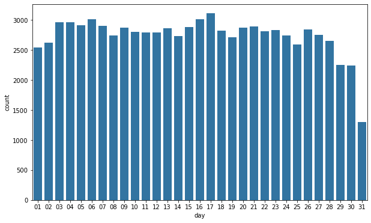

```python
ordered_countploting(loan_df.day,['01','02','03','04','05','06','07','08','09','10','11','12','13','14','15','16','17','18','19','20','21','22','23','24','25','26','27','28','29','30','31']);
```

I notice here that most loans were taken between October and January, that is msotly by year end. Also people took more loans in 2013 and on 16th and 17th day of a month.

### Next, I will check the distribution of the numeircal data in the dataset which include borrowerAPR, original amount, StatedMonthlyIncome, Term.

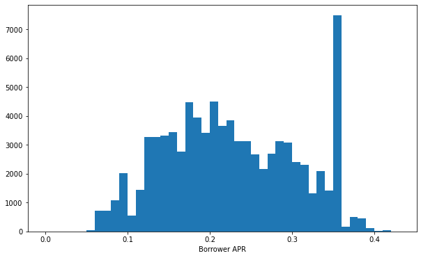

```python
## checking distribution for BorrowerAPR
bin_array = np.arange(0, loan_df.BorrowerAPR.max()+0.01, 0.01)
plt.figure(figsize=[10, 6])
plt.hist(data = loan_df, x = 'BorrowerAPR', bins = bin_array);
plt.xlabel('Borrower APR');
```

From here, I can see that there is a very high peak of data points for the APR between 0.35 and 0.36. Otherwise the distribution would have been bimodal.

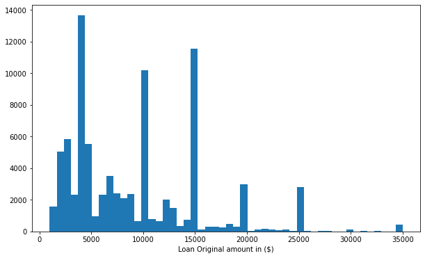

```python
#checking the distribution for Loan Original AMount
plt.figure(figsize=[10, 6])
plt.hist(loan_df['LoanOriginalAmount'], bins = 50);
plt.xlabel('Loan Original amount in ($)');
```

We can see here that the major peaks are on 4000, 10000 and 15000 which are the loans most people took.

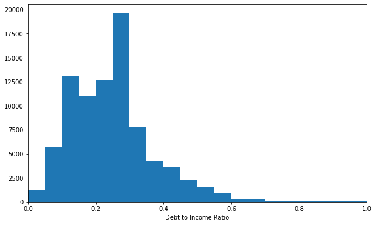

```python
## checking distribution for Debt income ratio

bin_array = np.arange(0, loan_df.DebtToIncomeRatio.max()+0.05, 0.05)
plt.figure(figsize=[10, 6])
plt.hist(loan_df.DebtToIncomeRatio, bins = bin_array)
plt.xlabel('Debt to Income Ratio')
plt.xlim(0,1);
```

Here, I noticed a peak for the debt to income ratio at around 0.3 This means that a good portion of the loan was distributed to people who took a loan worth 33.3% of their income. This is actually a financial best practice, as one shouldn't overburden themselves with a lot of debt.

Also, the frequencies after the ratio of 0.3 reduced, as it will be more difficult to keep up with repaying such loans.

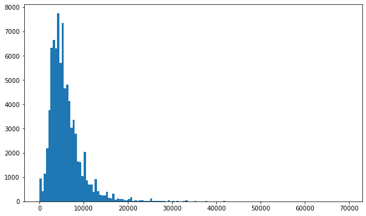

```python
# distribution of the stated monthly income
bins_array = np.arange(0, 70000, 500)
plt.figure(figsize=[10, 6])
plt.hist(loan_df.StatedMonthlyIncome, bins=bins_array);
```

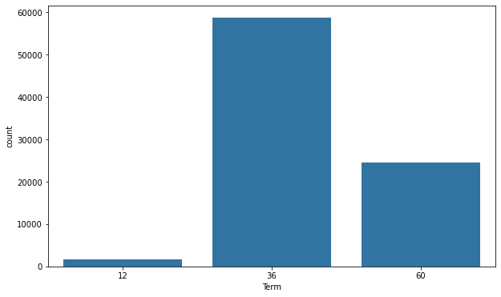

```python
##Reviewing the term
countploting(loan_df.Term);
```

The short term loan of 12 months was rarely taken, while the mid term loans were favoured, most people took loans with a term of 36 months.

### I will check the distribution of qualitative data in the dataset which include employment status, occupation, prosper rating and home owner status

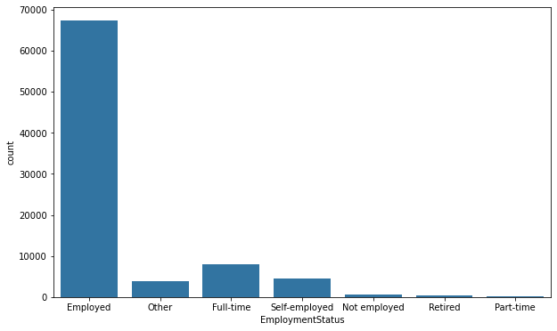

```python
## Checking for the distribution of employment status
countploting(loan_df.EmploymentStatus);
```

From this chart, I observed that most of the borrowers were employed.

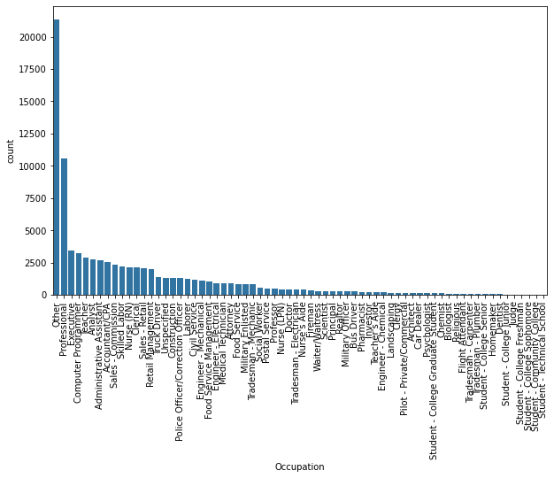

```python
## Checking for the distribution of the occupation
occupation_order = loan_df.Occupation.value_counts().index
ordered_countploting(loan_df.Occupation,occupation_order)
plt.xticks(rotation = 90);
```

The most frequent borrowers are professionals, executives, programmers and teachers. While the least are mostly students.

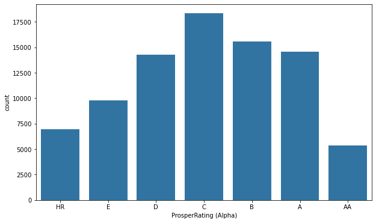

```python
## Checking for the distribution of the prosper rating

##first convert the rating to ordered categorical datatype.

rating_order = ['HR','E','D','C','B','A','AA']
rating_dtype = pd.api.types.CategoricalDtype(ordered = True,
                                    categories = rating_order)
loan_df['ProsperRating (Alpha)'] = loan_df['ProsperRating (Alpha)'].astype(rating_dtype)

##ploting the graph
countploting(loan_df['ProsperRating (Alpha)']);
```

Most of the borrowers fall between the D and A rating, with C the highest.`

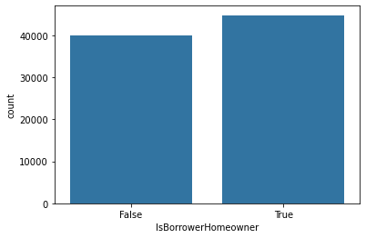

```python
##Checking for the loan status
base_color = sb.color_palette()[0]
sb.countplot(loan_df['IsBorrowerHomeowner'],color = base_color);
```

A slightly higher percentage of the borrowers are home owners

### Discuss the distribution(s) of your variable(s) of interest. Were there any unusual points? Did you need to perform any transformations?

> There werent unusual points for me, and I did not perform transformations to the data for the charts. However, I had to chnage the datatype of the month and prosper rating to categorical data.

### Of the features you investigated, were there any unusual distributions? Did you perform any operations on the data to tidy, adjust, or change the form of the data? If so, why did you do this?

> Monthly income was skewed to the right, but that was not very unusual.Debt to income also was skewed to the right.

## Bivariate Exploration

> I will start off with reviewing relationship between different features of the datasef

```python
## categorizing the data
numerical_features = ['LoanOriginalAmount', 'BorrowerAPR', 'StatedMonthlyIncome','DebtToIncomeRatio']
categorical_features = ['Term','ProsperRating (Alpha)', 'EmploymentStatus','Occupation','IsBorrowerHomeowner']
```

### Plotting to observe the correlation beteween the numerical variables

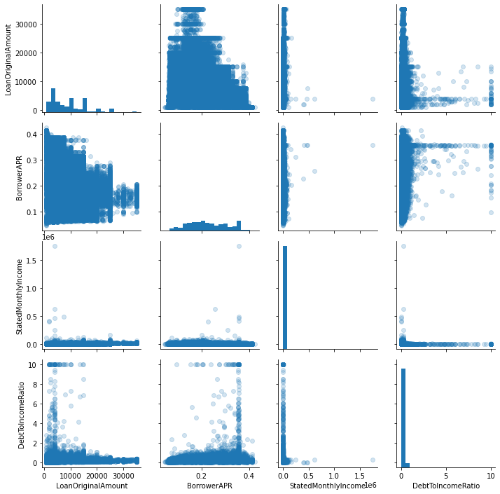

```python
g = sb.PairGrid(data = loan_df, vars = numerical_features)
g = g.map_diag(plt.hist, bins=20)
g.map_offdiag(plt.scatter, alpha=0.2);
```

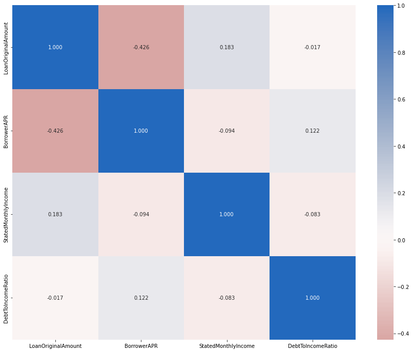

```python
# correlation plot
plt.figure(figsize = [15, 12])
sb.heatmap(loan_df[numerical_features].corr(), annot = True, fmt = '.3f',cmap = 'vlag_r', center = 0);
```

BorrowerAPR and the loan amount have a negative correlation of -0.426. This is in line with my experience in the financial industry, as the higher the loan amount, the lower the interest rates.

The loan amount has a positive correlation with stated income.

### Relationship between borrowerAPR, employment status, home owner, and term

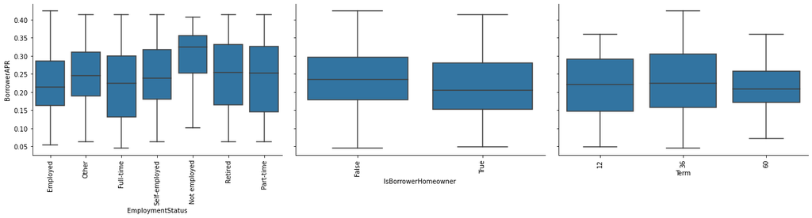

```python
##defining the boxgrid function
def boxgrid(x, y, **kwargs):
    base_color = sb.color_palette()[0]
    sb.boxplot(x, y, color = base_color)
    plt.xticks(rotation=90);

g = sb.PairGrid(data = loan_df, x_vars=['EmploymentStatus','IsBorrowerHomeowner','Term'],y_vars='BorrowerAPR', size=4, aspect=1.5)
g.map(boxgrid);
```

### Relationship between the numerical variables and occupation

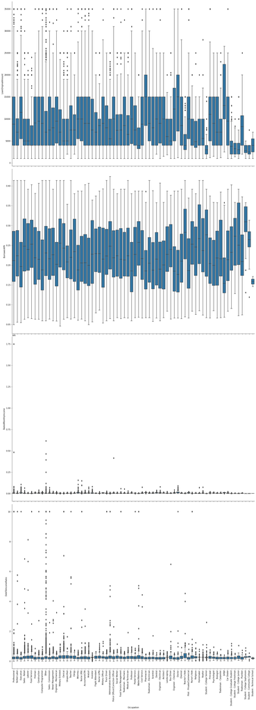

```python
g = sb.PairGrid(data = loan_df, x_vars=['Occupation'], y_vars=numerical_features, size = 12, aspect=1.5)
g.map(boxgrid)
```

From the plots above, I noticed the following:

1. Students had access to the least loan amounts
2. Students also had the least stated montly income. Earlier, I noticed a positive correlation between loan amounts and montly income. It is therefore a fair prediction that the lower the stated income, the lower the loan amounts accessible to a borrower.

### Relationship between (term, prosper rating and employment status) and numerical features

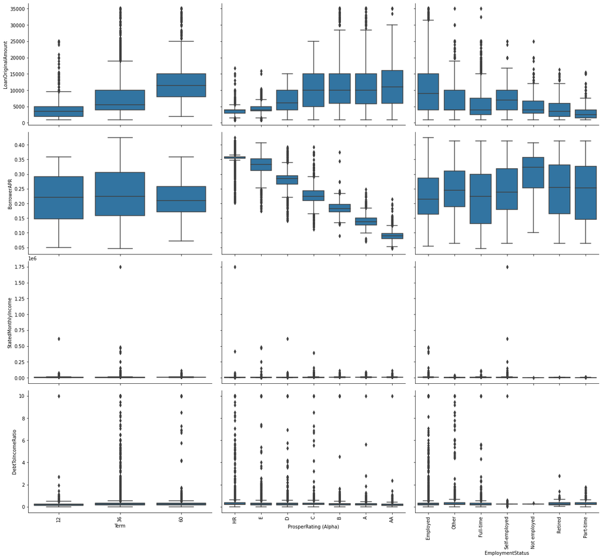

```python
g = sb.PairGrid(data = loan_df, x_vars =['Term','ProsperRating (Alpha)','EmploymentStatus'], y_vars = numerical_features, size = 4,aspect = 1.5)
g.map(boxgrid)
```

From the plots above, I noticed that:

1. The higher the term, the higher the loan amount that can be availed a borrower.
2. The better the Prosper Rating, the lower the borrower rates
3. Also borrowers with better Prosper Ratings can get loans with higher amounts.

### Borrower Rates over the years

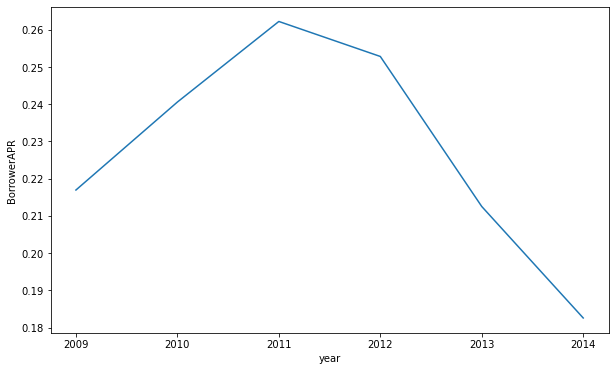

```python
## making year date time, referenced stackexchange on how to format year alone to date time
loan_df.year = pd.to_datetime(loan_df.year, format = '%Y')
loan_df.year = loan_df.year.dt.year

##using a pointplot to see the relationship
plt.figure(figsize=[10,6])
sb.lineplot(data= loan_df, x = 'year', y = 'BorrowerAPR', ci =None);
```

The plot shows a trend, the borrower rates increased up to 2011 where it was highest and dropped to 2014 where it is relatively low.

### Relationship between some categorical variables

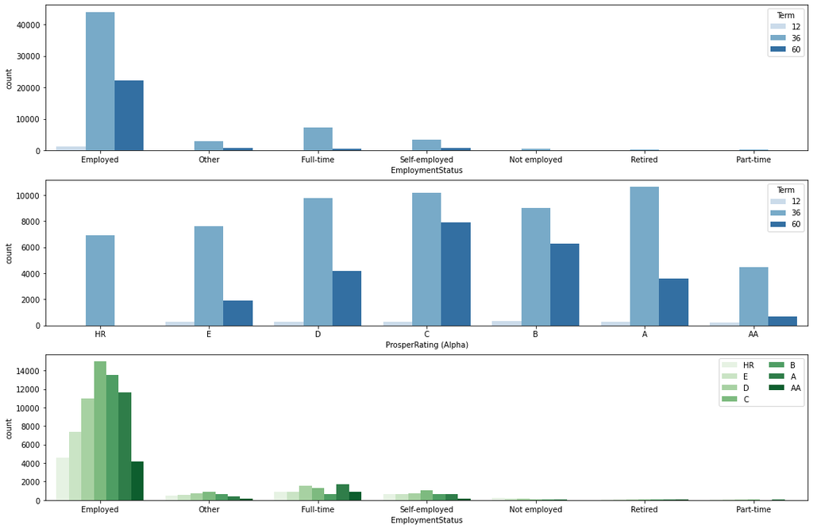

```python
plt.figure(figsize = [18, 12])

# subplot 1: employment status vs term
plt.subplot(3, 1, 1)
sb.countplot(data = loan_df, x = 'EmploymentStatus', hue = 'Term', palette = 'Blues')
plt.xticks()

# subplot 2: prosper rating vs. term
ax = plt.subplot(3, 1, 2)
sb.countplot(data = loan_df, x = 'ProsperRating (Alpha)', hue = 'Term', palette = 'Blues')
plt.xticks()


# subplot 3: Prosper rating vs. employment status
ax = plt.subplot(3, 1, 3)
sb.countplot(data = loan_df, x = 'EmploymentStatus', hue = 'ProsperRating (Alpha)', palette = 'Greens')
##rearrange the legend to avoid it overlapping
ax.legend(loc = 1, ncol = 2);
plt.xticks();
```

### Talk about some of the relationships you observed in this part of the investigation. How did the feature(s) of interest vary with other features in the dataset?

> The Prosper rating also has a high impact on borrower rates, the higher the prosper rating, the lower the rates applicable to the borrower

### Did you observe any interesting relationships between the other features (not the main feature(s) of interest)?

> I observed that there is a positive correlation between loan amount and stated income. The more income one has, the higher they can borrow and stay in line with the average debt to income ratio of 33.3% Employed and full time borrowers have a relatively higher prosper rating compared to others.

## Multivariate Exploration

> Create plots of three or more variables to investigate your data even further. Make sure that your investigations are justified, and follow from your work in the previous sections.

### Relationship between borrower rate, years and being a home owner or not

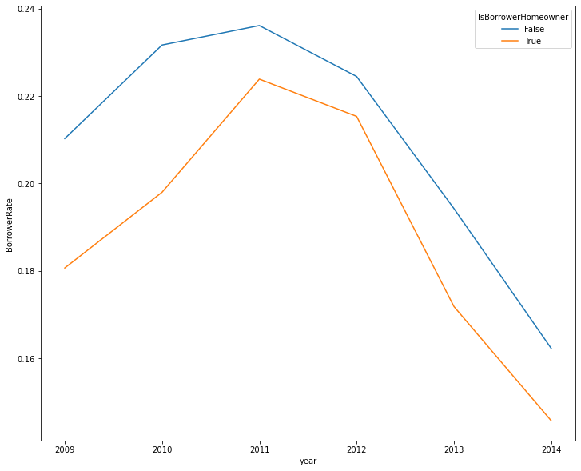

```python
plt.figure(figsize=[12,10])

##plotting a lineplot to serve as time series
sb.lineplot(data=loan_df, x='year', y='BorrowerRate', hue='IsBorrowerHomeowner',ci=None);
```

From the plot above, home owners who can mortgage their homes as collateral can access lower rates than others. The difference in the rates to home owners and non home owners was really high between 2009 and 2010. the difference however reduced as from 2011.

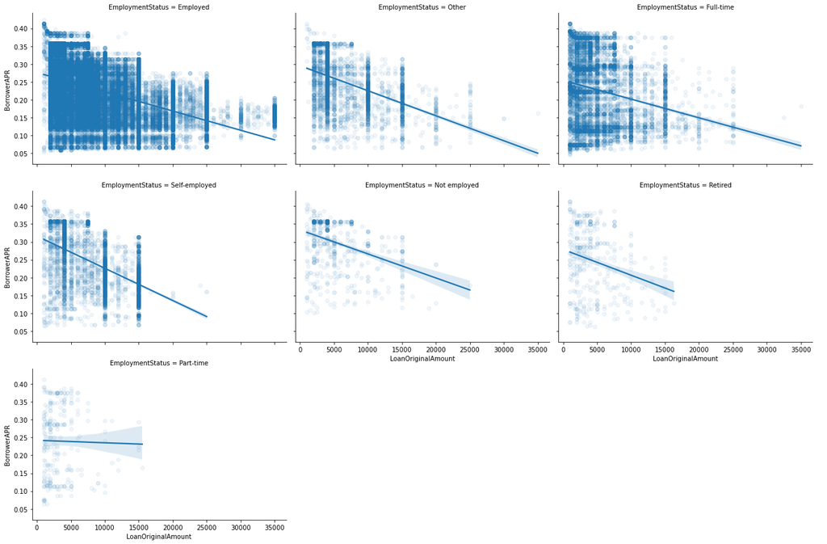

```python
g=sb.FacetGrid(data= loan_df, aspect=1.5, size=4, col='EmploymentStatus', col_wrap=3)
g.map(sb.regplot, 'LoanOriginalAmount', 'BorrowerAPR', x_jitter=0.04, scatter_kws={'alpha':1/15});
g.add_legend();
```

### Relationship between loan amount, borrower rate, prosper rating and Employment status

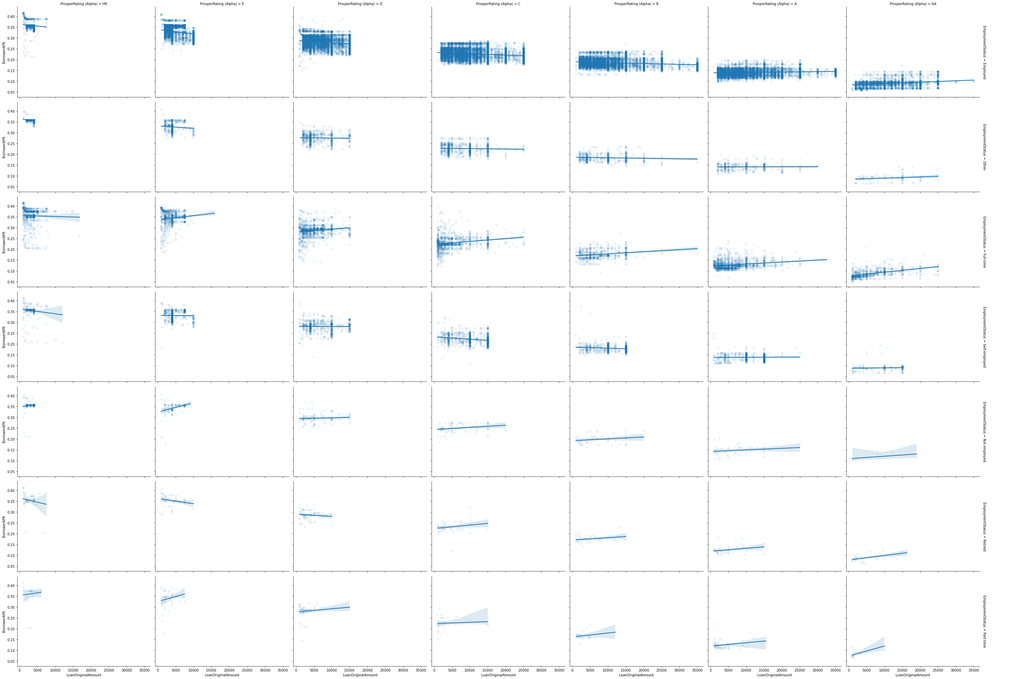

```python
g=sb.FacetGrid(data= loan_df, aspect=1.5, size=4, col='ProsperRating (Alpha)', row = 'EmploymentStatus', margin_titles=True)
g.map(sb.regplot, 'LoanOriginalAmount', 'BorrowerAPR', x_jitter=0.04, scatter_kws={'alpha':1/15});
g.add_legend();
```

I noticed the following:

1. Prosper rating has a very strong influence on borrower rates and loan amount. The highest prosper rated borrowers enjoyed lower rates compared to other ratings.
2. Employed borrowers with the highest rating almost enjoyed fixed rates regardless of the loan amount and they could be charged higher rates with higher loan amounts.

### Talk about some of the relationships you observed in this part of the investigation. Were there features that strengthened each other in terms of looking at your feature(s) of interest?

> In the multivariate exploration of data, I observed that prosper rating and employment status affect loan amount and rate. Borrower Rates decrease across all employment status, as the prosper rating for the borrower increases. However, as the employement status improves, with a higher prosper rating, the general trend where loan amount varies inversely with borrower rate changes. Instead, it becomes the higher the amount, there is a higher or near constant rate. The trend above does not appear to apply for part-time employees. They generally get a higher or near constant rate as the loan amount increases.

### Were there any interesting or surprising interactions between features?

> I observed that the borrower rate for home owners and non home owners decreased from 2011.

```python
loan_df.to_csv('LoanData_cleaned.csv')
```

In conclusion, I was able to explore the data with univariate, bivariate and multivariate plots.